# UML: Aktivitätsdiagramm Use-Case-Diagramm

## Lokaler Computer-Experte …

[figure not shown]

Kein echtes UML!

Quelle: xkcd.com/627/

## UML Diagramm-Übersicht

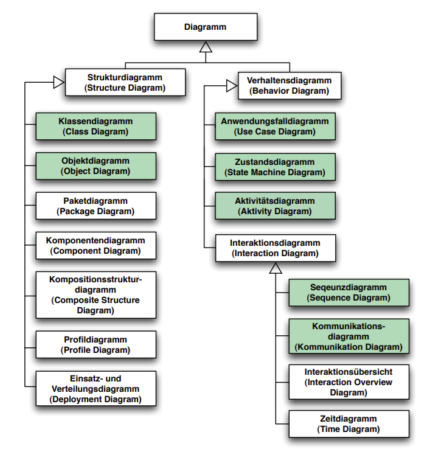

Quelle: esb-dev.github.io

## Ein “echtes” Aktivitätsdiagramm

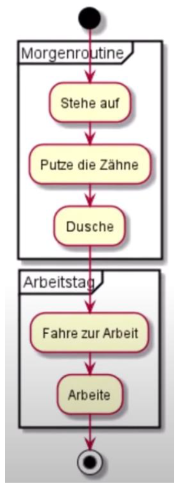

- bildet die von einem System ausgeführten Aktivitäten ab
- zählt zu den **Verhaltensdiagrammen** in der UML

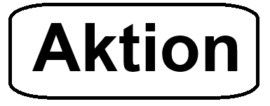

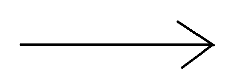

Startknoten  
Aktion  
Konnektor  
Endknoten

## Aufgabe: Bibliothek

Stellen Sie sich vor, Sie besuchen die Bibliothek, um ein Buch auszuleihen.

Erstellen Sie ein Aktivitätsdiagramm, das den gesamten Ablauf Ihres Besuchs in der Bibliothek beschreibt.

- Sie betreten die Bibliothek.
- Sie gehen zur Buchabteilung und suchen ein Buch.
- Sie prüfen, ob das Buch ausleihbar ist.
- Sie verlassen die Bibliothek.

**Erstellen Sie das Aktivitäts-Diagramm mit draw.io. Speichern Sie es so, dass Sie es in der Folge weiter nutzen und verändern können.**

## Lösung: Bibliothek

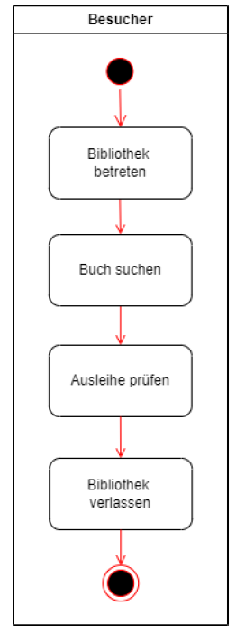

## Aktivitätsdiagramm: Verzweigung

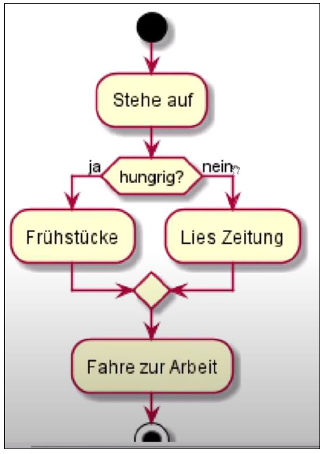

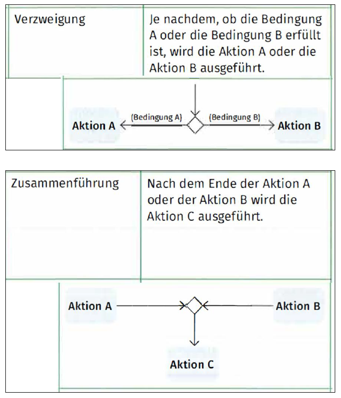

## Aufgabe: Bibliothek, Verzweigung

Sie besuchen die Bibliothek, um ein Buch auszuleihen.

Erstellen Sie ein Aktivitätsdiagramm **mit Verzweigung**.

- Sie betreten die Bibliothek.
- Sie suchen und finden ein Buch.
- Sie prüfen, ob es ausleihbar ist.
- Wenn ja (Buch ausleihbar):
  - Sie gehen zur Ausleihtheke.
  - Sie leihen das Buch aus.
  - Sie verlassen die Bibliothek.
- Wenn nein (Buch nicht ausleihbar):
  - Prüfen, ob Sie noch ein anderes Buch suchen
  - Falls ja:
    - Buch suchen
  - Falls nein:
    - Sie verlassen die Bibliothek.

## Lösung: Bibliothek, Verzweigung

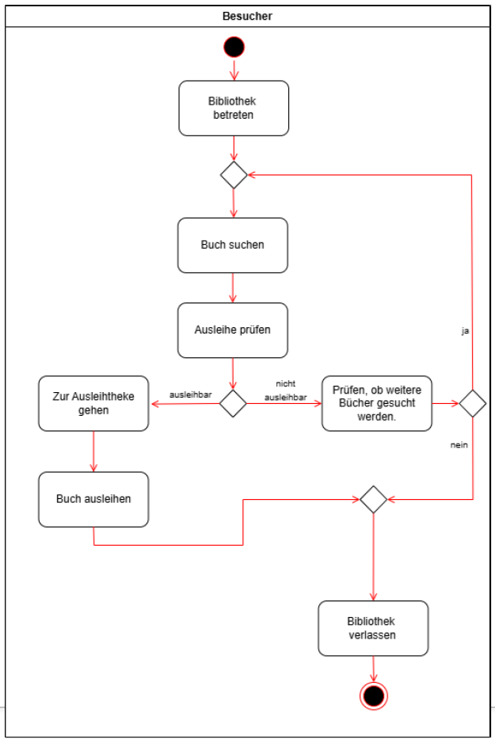

### Aktivitätsdiagramm: Parallele Verarbeitung

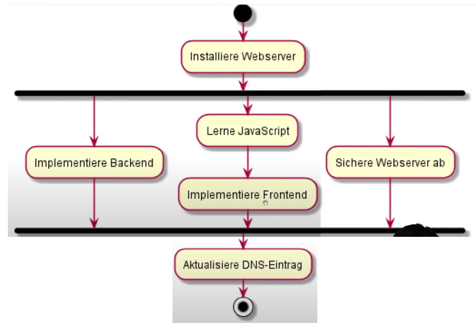

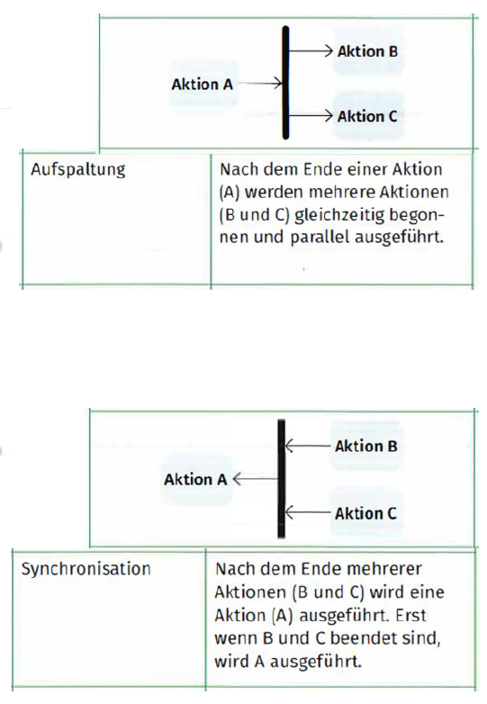

## Aufgabe: Bibliothek, parallel

#### Wie zuletzt

Sie besuchen die Bibliothek, um ein Buch auszuleihen.

- Sie betreten die Bibliothek.
- Sie suchen und finden ein Buch.
- Sie prüfen, ob es ausleihbar ist.
- Wenn ja (Buch ausleihbar):
  - Sie gehen zur Ausleihtheke.
  - Sie leihen das Buch aus.
  - Sie verlassen die Bibliothek.
- Wenn nein (Buch nicht ausleihbar):
  - Prüfen, ob Sie noch ein anderes Buch suchen
  - Falls ja:
    - Buch suchen
  - Falls nein:
    - Sie verlassen die Bibliothek.

#### Neu

Nach der Ausleihe laufen vor dem Verlassen der Bibo zwei Prozesse parallel:

- Bibliotheksdatenbank muss das ausgeliehene Buch registrieren
- Arbeitskraft am Schalter stellt Ausleihbeleg aus.

## Lösung: Bibliothek, parallel

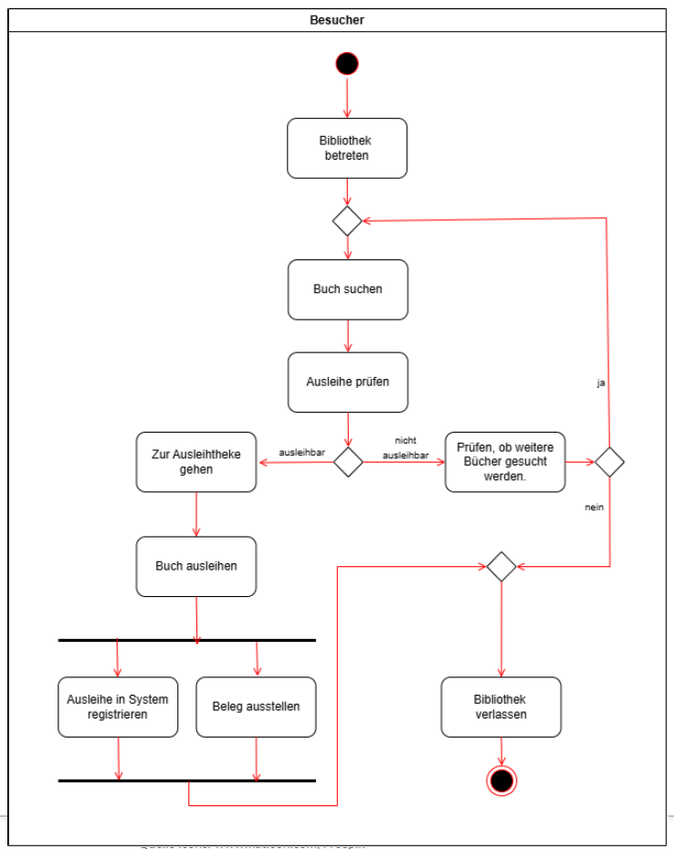

### Aktivitätsdiagramm: Swimlanes für Akteure

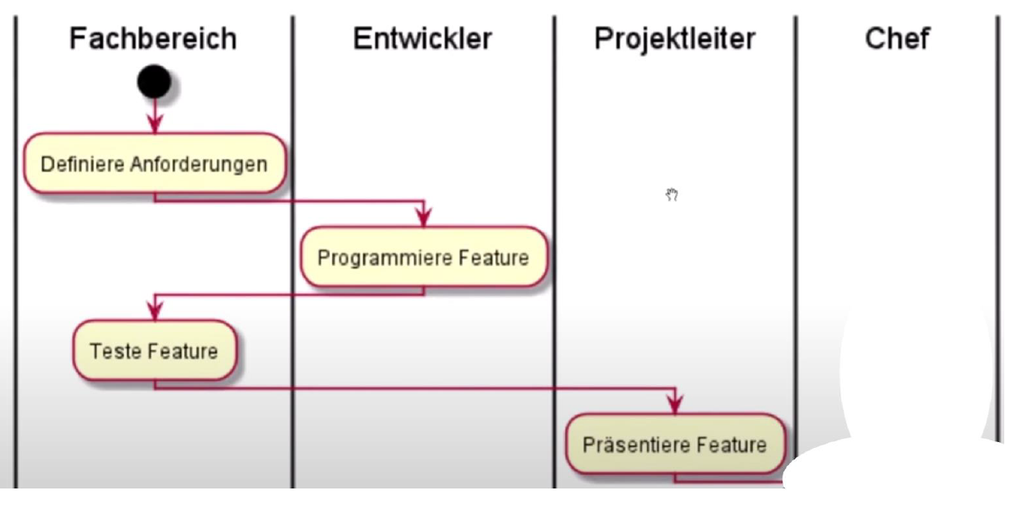

Swimlanes zeigen in Spaltenform, **wer** oder **welches System** für die jeweilige Aktivität zuständig ist.

## Aufgabe: Bibliothek mit Swimlanes

Diagramm wie bisher, mit parallelen Prozessen vor dem Verlassen der Bibliothek.

**Neu: Kennzeichnen Sie die Verantwortlichkeiten anhand von Swimlanes.**

## Lösung: Bibliothek mit Swimlanes

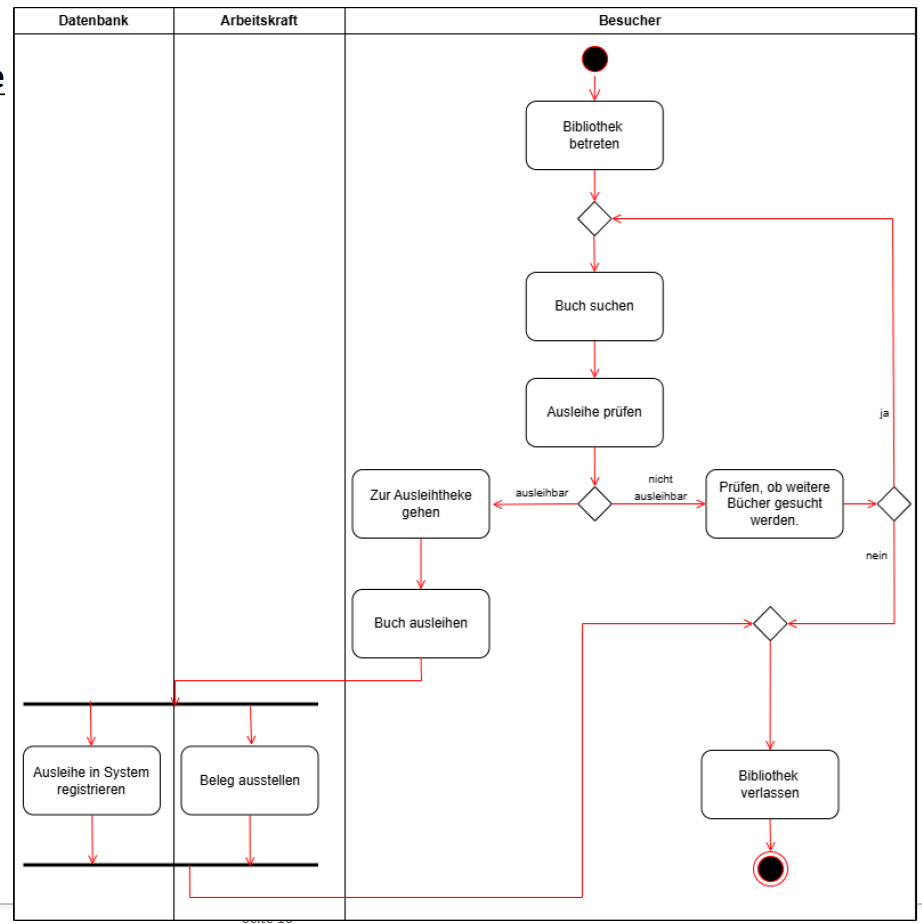

## Aktivitätsdiagramm: Übersicht

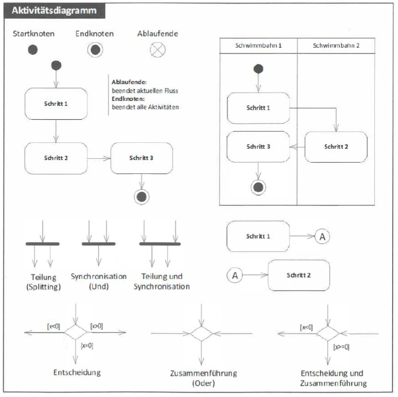

## Anwendungsfalldiagramme

#### Was ist ein Anwendungsfall?

- Verhalten, das ein modelliertes System nach außen anbietet
- Perspektive: Nutzer

#### Was ist ein Anwendungsfall-Diagramm *(Use-Case-Diagramm)*?

- Zeigt das externe Verhalten eines Systems aus Sicht der Nutzer
- Beantwortet die Frage:  
  *Was soll mein geplantes System eigentlich leisten?*

## Anwendungsfalldiagramm: Yachthafen

### Liegeplatzverwaltung

- Projekt: Softwarekomponente für Vermietung von Liegeplätzen
- Teil des Yachthafen-Managements

Anforderungen:

- Kunden können Liegeplatz mieten und kündigen
- Kunden können sich im Yachthafen mit Yacht an- und abmelden
- Mitarbeiter können einzelne Liegeplätze für Wartung sperren
- Nutzer des Programms können aktuelle Liegeplatzbelegung ansehen

Projektteam:

- objektorientierte Entwicklung
- UML zur Planung

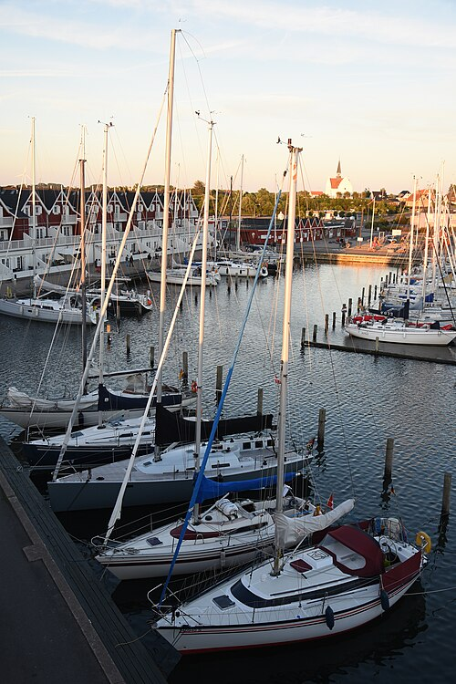

Quelle: PaterMcFly, Wikimedia Commons

Nächster Schritt in Softwareentwicklung?  
Wie können sich Entwickler einen Überblick über alle Anwendungsfälle verschaffen?

## Anwendungsfalldiagramm: Yachthafen

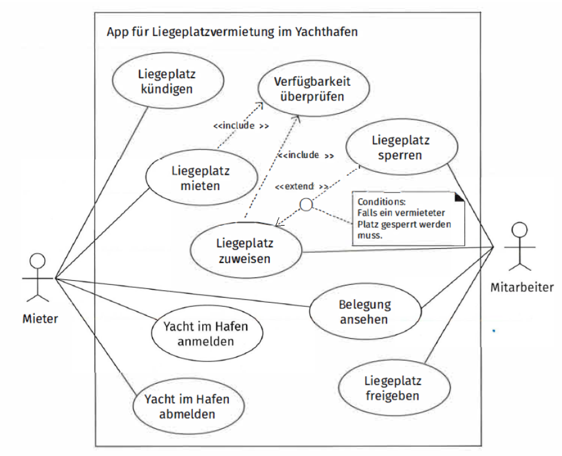

## Use-Case-Diagramm: Grundelemente

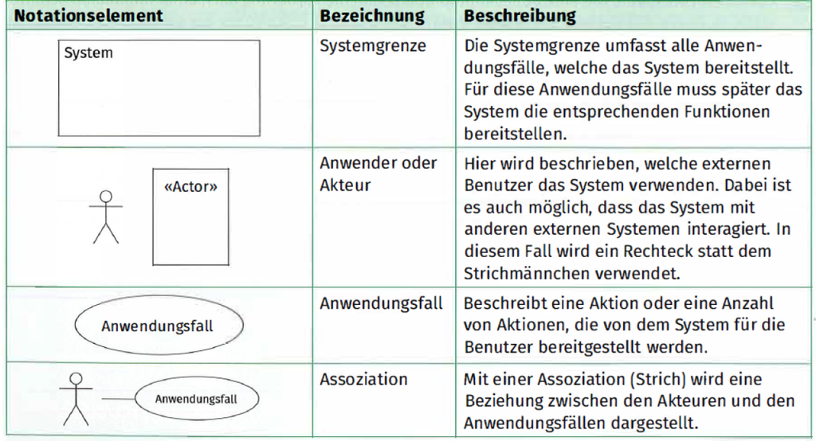

## Use-Case-Diagramm: Generalisierung

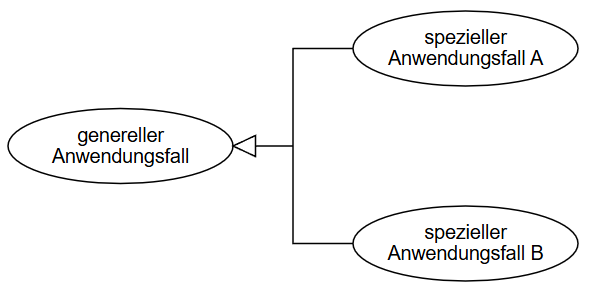

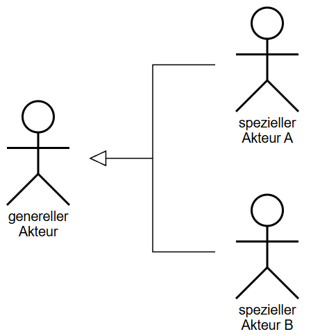

#### Generalisierung / Spezialisierung

- zeigt Beziehung zwischen allgemeinem und spezialisiertem Element
- kann sowohl zwischen Anwendungsfällen als auch zwischen Akteuren dargestellt werden
- **Pfeilrichtung** beachten:  
  *Vom speziellen zum generellen Element!*

## Aufgabe: Use-Case-D. Bibliothek

Bibliothek möchte neues System einführen zur Automatisierung:

- Ausleihe von Büchern
- Benutzerverwaltung
- Bücherverwaltung

**Aufgabe: Use-Case-Diagramm**

#### Anforderungen

- **Benutzer** kann Bücher ausleihen, Bücher zurückgeben und seinen Kontostand für ausgeliehene Bücher überprüfen
- **Premium-Benutzer** kann **zusätzlich** Bücher vorbestellen
- **Bibliothekar** kann neue Benutzer registrieren, Bücher hinzufügen und Bücher entfernen
- **Chef-Bibliothekar** kann **zusätzlich** Berichte über die Ausleihe erstellen und die Verwaltung der Bibliothek übernehmen

## Lösung: Use-Case-D. Bibliothek

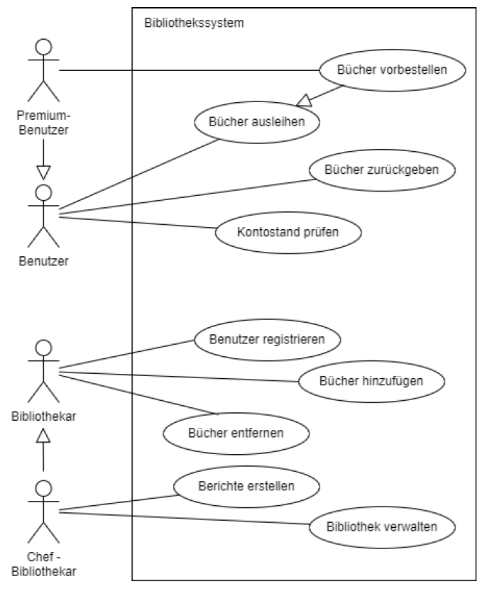

## Use-Case-D.: <<include>>

[figure not shown]

- Ein Anwendungsfall führt **immer** einen anderen mit aus
- Pflicht-Einbindung
- includierter Use Case ist wiederverwendbar
- Pfeilrichtung:  
  vom Basis-Use-Case zum inkludierten Use-Case

## Aufgabe: Use-Case-D., include

Bibliothek, wie zuletzt

#### Neue Beziehungen

- Ausleihen von Büchern enthält immer **Berechtigungs-Prüfung**
- Registrieren eines Benutzers: immer **Bestätigungs-Email**

Use-Case-Diagramm zeichnen.

## Lösung: Use-Case-D., include

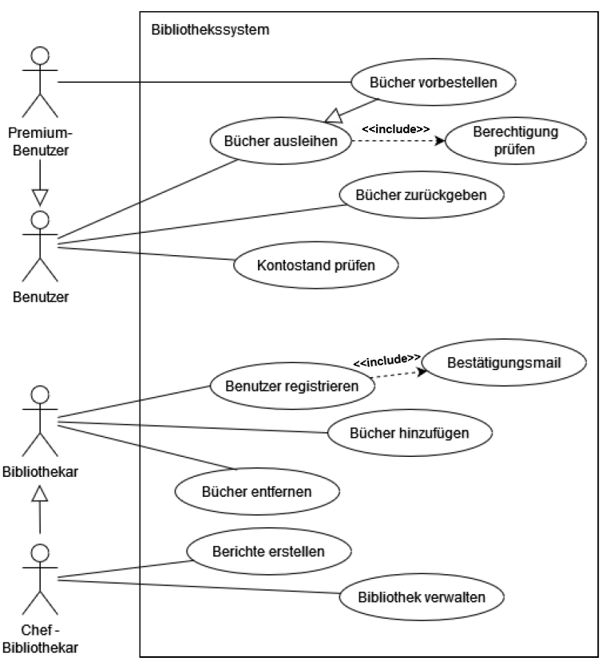

## Use-Case-D.: <<extend>>

[figure not shown]

- Ein Anwendungsfall führt **optional** einen anderen mit aus
- Erweiterung **unter bestimmten Bedingungen**
- Achtung: Pfeilrichtung  
  vom erweiternden Anwendungsfall zum Basis-Use-Case
- Anders als bei <<include>>!!
- B ist Basis-Use-Case, A ist *extended use case*

[figure not shown]

## Aufgabe: Use-Case-D., extend

Bibliothek, wie zuletzt, mit include

#### Neue Sonderfälle

- Bücher zurückgeben: manchmal müssen Gebühren erhoben werden  
  -> erweitert den Use Case “Bücher zurückgeben”
- Wenn Bibliothekar ein Buch hinzufügt:  
  manchmal müssen Buchinformationen validiert werden,  
  wenn sie unvollständig sind

Aufgabe: Use-Case-Diagramm mit zwei *Conditions*

## Lösung: Use-Case-D., extend

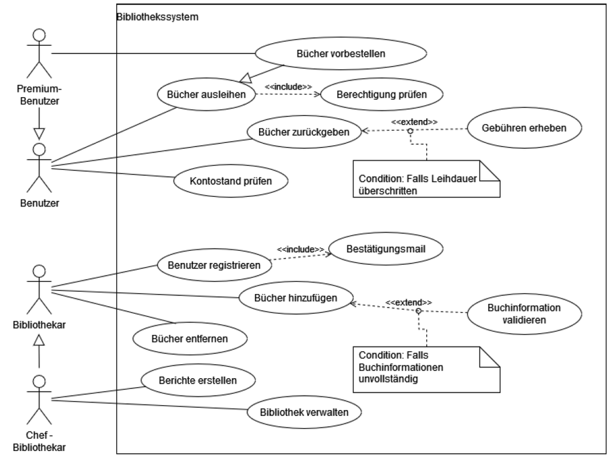

## Use-Case-Diagramm: So klappt’s

- **Include** (zwingende Folge) und **extend (optionale Folge)** gut unterscheiden
- **Pfeilrichtungen** beachten:
  - Generalisierung / Spezialisierung: Vom speziellen zum generellen Element  
    Beispiel: vom *Premium-Benutzer* zum *Benutzer*
  - <<include>>: vom Basis-Use-Case zum inkludierten Use-Case  
    Beispiel: von *Bücher ausleihen* zu *Berechtigung prüfen*
  - <<extend>>: vom erweiternden Anwendungsfall zum Basis-Use-Case  
    Beispiel: von *Gebühren erheben* zu *Bücher zurückgeben*
- Use-Case-Diagramm ist **statisch**  
  Nicht für *Abläufe* verwenden!

## Vielen Dank!

**Viel Erfolg mit UML!**

Zurück zur Übersicht LF5